# Household Survey Analysis - Parks Questions

Preliminary Results

Published

June 18, 2025

This document presents an initial analysis of the household survey responses from invited residents living within 0.1 mile (0.16 km) of Lafayette Park in Norfolk and Paradise Creek Nature Park in Portsmouth.

The survey itself was constructed using Qualtrics and participants were recruited using mailed postcards, email, and [SMS text messaging](https://rumbleup.com). The household survey response rate was lower than expected, despite compensation in the form of a $35 gift card as a financial incentive and we received 93 responses from 486 invitations for a response rate of 19.1% percent.

This webpage accompanies an earlier preliminary analysis of the remaining questions from the household survey [which can be accessed here](https://bw6xs.github.io/CoPE/surveyanalysiswellbeing.html).

There are several sets of questions designed to capture people’s perceptions of the two parks considered as well as their satisfaction with those green spaces. The section below outlines how these question responses were coded to support analysis.

#### Perceptions of the Parks

For this battery of questions, all responses were collapsed from the original 5-point scale (**1 = Strongly disagree, 2 = Somewhat disagree, 3 = Neither agree nor disagree, 4 = Somewhat agree, 5 = Strongly agree**) to a 3-point scale **1 = Strongly *or* somewhat disagree, 2 = Neither agree nor disagree, 3 = Somewhat *or* strongly agree**:

- There is much to explore and discover here
- This is a place to getaway from the things that usually demand my attention
- I can see and enjoy wildlife in this local park
- It is free from litter, graffiti and is well maintained
- There is a range of good facilities
- The facilities (e.g., playground equipment, sports fields) align with the needs of people who live in my neighborhood
- It is attractive and pleasant to visit
- I feel safe visiting during daylight hours

```r
kbl(
recoded_data_parks %>%
  group_by(City) %>%
  dplyr::select(Much_Discover, Get_Away, See_Wildlife, Well_Maintained,
                 Variety_Facilities, Facilities_Align, Attractive_Pleasant, Feel_Safe, City) %>%
  `colnames<-`(c("There Is Much To Discover", "This Is A Place To Get Away", "I Can See Wildlife", "It Is Well Maintained",
                 "It Has A Variety Of Facilities", "Facilities Align With My Neighborhood", "It Is Attractive + Pleasant", "I Feel Safe Visiting", "City")) %>%
  rstatix::get_summary_stats(show = c("min", "max", "mean", "sd"))
) %>%
  kable_paper(bootstrap_options = "striped", full_width = F)
```

| City | variable | n | min | max | mean | sd |
| --- | --- | --- | --- | --- | --- | --- |
| Norfolk | There Is Much To Discover | 54 | 1 | 3 | 2.481 | 0.795 |
| Norfolk | This Is A Place To Get Away | 54 | 1 | 3 | 2.648 | 0.705 |
| Norfolk | I Can See Wildlife | 54 | 1 | 3 | 2.407 | 0.836 |
| Norfolk | It Is Well Maintained | 54 | 1 | 3 | 2.241 | 0.930 |
| Norfolk | It Has A Variety Of Facilities | 54 | 1 | 3 | 2.519 | 0.771 |
| Norfolk | Facilities Align With My Neighborhood | 54 | 1 | 3 | 2.722 | 0.596 |
| Norfolk | It Is Attractive + Pleasant | 54 | 1 | 3 | 2.648 | 0.705 |
| Norfolk | I Feel Safe Visiting | 53 | 1 | 3 | 2.774 | 0.640 |
| Portsmouth | There Is Much To Discover | 36 | 1 | 3 | 2.528 | 0.736 |
| Portsmouth | This Is A Place To Get Away | 36 | 1 | 3 | 2.528 | 0.696 |
| Portsmouth | I Can See Wildlife | 36 | 1 | 3 | 2.444 | 0.773 |
| Portsmouth | It Is Well Maintained | 36 | 1 | 3 | 2.417 | 0.770 |
| Portsmouth | It Has A Variety Of Facilities | 36 | 1 | 3 | 2.250 | 0.806 |
| Portsmouth | Facilities Align With My Neighborhood | 36 | 1 | 3 | 2.278 | 0.741 |
| Portsmouth | It Is Attractive + Pleasant | 36 | 1 | 3 | 2.639 | 0.639 |
| Portsmouth | I Feel Safe Visiting | 36 | 1 | 3 | 2.583 | 0.649 |

```r
kruskal_test(data = recoded_data_parks, formula = Much_Discover ~ City)
```

```
# A tibble: 1 × 6
  .y.               n statistic    df     p method
* <chr>         <int>     <dbl> <int> <dbl> <chr>
1 Much_Discover    93    0.0220     1 0.882 Kruskal-Wallis
```

```r
wilcox_test(formula = Much_Discover ~ City, data = recoded_data_parks)
```

```
# A tibble: 1 × 7
  .y.           group1  group2        n1    n2 statistic     p
* <chr>         <chr>   <chr>      <int> <int>     <dbl> <dbl>
1 Much_Discover Norfolk Portsmouth    54    36       957 0.886
```

```r
kruskal_test(data = recoded_data_parks, formula = Get_Away ~ City)
```

```
# A tibble: 1 × 6
  .y.          n statistic    df     p method
* <chr>    <int>     <dbl> <int> <dbl> <chr>
1 Get_Away    93      1.41     1 0.234 Kruskal-Wallis
```

```r
wilcox_test(formula = Get_Away ~ City, data = recoded_data_parks)
```

```
# A tibble: 1 × 7
  .y.      group1  group2        n1    n2 statistic     p
* <chr>    <chr>   <chr>      <int> <int>     <dbl> <dbl>
1 Get_Away Norfolk Portsmouth    54    36     1086. 0.236
```

```r
kruskal_test(data = recoded_data_parks, formula = See_Wildlife ~ City)
```

```
# A tibble: 1 × 6
  .y.              n statistic    df     p method
* <chr>        <int>     <dbl> <int> <dbl> <chr>
1 See_Wildlife    93   0.00328     1 0.954 Kruskal-Wallis
```

```r
wilcox_test(formula = See_Wildlife ~ City, data = recoded_data_parks)
```

```
# A tibble: 1 × 7
  .y.          group1  group2        n1    n2 statistic     p
* <chr>        <chr>   <chr>      <int> <int>     <dbl> <dbl>
1 See_Wildlife Norfolk Portsmouth    54    36       966 0.958
```

```r
kruskal_test(data = recoded_data_parks, formula = Well_Maintained ~ City)
```

```
# A tibble: 1 × 6
  .y.                 n statistic    df     p method
* <chr>           <int>     <dbl> <int> <dbl> <chr>
1 Well_Maintained    93     0.486     1 0.486 Kruskal-Wallis
```

```r
wilcox_test(formula = Well_Maintained ~ City, data = recoded_data_parks)
```

```
# A tibble: 1 × 7
  .y.             group1  group2        n1    n2 statistic     p
* <chr>           <chr>   <chr>      <int> <int>     <dbl> <dbl>
1 Well_Maintained Norfolk Portsmouth    54    36       897 0.488
```

```r
kruskal_test(data = recoded_data_parks, formula = Variety_Facilities ~ City)
```

```
# A tibble: 1 × 6
  .y.                    n statistic    df      p method
* <chr>              <int>     <dbl> <int>  <dbl> <chr>
1 Variety_Facilities    93      3.17     1 0.0749 Kruskal-Wallis
```

```r
wilcox_test(formula = Variety_Facilities ~ City, data = recoded_data_parks)
```

```
# A tibble: 1 × 7
  .y.                group1  group2        n1    n2 statistic      p
* <chr>              <chr>   <chr>      <int> <int>     <dbl>  <dbl>
1 Variety_Facilities Norfolk Portsmouth    54    36     1162. 0.0757
```

```r
kruskal_test(data = recoded_data_parks, formula = Facilities_Align ~ City)
```

```
# A tibble: 1 × 6
  .y.                  n statistic    df       p method
* <chr>            <int>     <dbl> <int>   <dbl> <chr>
1 Facilities_Align    93      10.8     1 0.00101 Kruskal-Wallis
```

```r
wilcox_test(formula = Facilities_Align ~ City, data = recoded_data_parks)
```

```
# A tibble: 1 × 7
  .y.              group1  group2        n1    n2 statistic       p
* <chr>            <chr>   <chr>      <int> <int>     <dbl>   <dbl>
1 Facilities_Align Norfolk Portsmouth    54    36      1307 0.00103
```

```r
kruskal_test(data = recoded_data_parks, formula = Attractive_Pleasant ~ City)
```

```
# A tibble: 1 × 6
  .y.                     n statistic    df     p method
* <chr>               <int>     <dbl> <int> <dbl> <chr>
1 Attractive_Pleasant    93     0.164     1 0.685 Kruskal-Wallis
```

```r
wilcox_test(formula = Attractive_Pleasant ~ City, data = recoded_data_parks)
```

```
# A tibble: 1 × 7
  .y.                 group1  group2        n1    n2 statistic     p
* <chr>               <chr>   <chr>      <int> <int>     <dbl> <dbl>
1 Attractive_Pleasant Norfolk Portsmouth    54    36      1009 0.689
```

```r
kruskal_test(data = recoded_data_parks, formula = Feel_Safe ~ City)
```

```
# A tibble: 1 × 6
  .y.           n statistic    df      p method
* <chr>     <int>     <dbl> <int>  <dbl> <chr>
1 Feel_Safe    93      4.77     1 0.0289 Kruskal-Wallis
```

```r
wilcox_test(formula = Feel_Safe ~ City, data = recoded_data_parks)
```

```
# A tibble: 1 × 7
  .y.       group1  group2        n1    n2 statistic      p
* <chr>     <chr>   <chr>      <int> <int>     <dbl>  <dbl>
1 Feel_Safe Norfolk Portsmouth    53    36      1137 0.0293
```

Surprisingly, there is no difference in responses to the *I can see and enjoy wildlife in this local park* question despite Paradise Creek Nature Park being more natural and forested.

There are statistically significant differences between Norfolk and Portsmouth respondents on the *The facilities (e.g.,playground equipment, sports fields) align with the needs of people who live in my neighborhood* question with responses higher on average in Norfolk. This seems to corroborate the hypothesis that the physical barrier that Granby Street and Victory Boulevard pose for residents is not the sole consideration when trying to understand differing usage rates. It could be that Cradock residents do not feel that the park and its facilities/characteristics fit their needs.

There are statistically significant differences between Norfolk and Portsmouth respondents on the *I feel safe visiting during daylight hours* question with responses higher on average in Norfolk. This appears to highlight a tension between greener, more heavily forested environments that are conducive to connecting with nature and safety concerns. While there are safety concerns voiced by Lafayette Park users, the environment is much more open with greater visibility and a higher number of other people in the park.

#### Satisfaction with the Parks

For the question below, a higher number represents greater satisfaction and are coded **1 = Extremely *or* somewhat dissatisfied, 2 = Neither satisfied nor dissatisfied, 3 = Extremely *or* somewhat satisfied**:

- How satisfied are you with the quality of [Lafayette or Paradise Creek Nature] Park?

```r
kbl(
recoded_data_parks %>%
  group_by(City) %>%
  dplyr::select(Quality_Park, City) %>%
  `colnames<-`(c("Satisfied with the Quality of Park", "City")) %>%
  rstatix::get_summary_stats(show = c("min", "max", "mean", "sd"))
) %>%
  kable_paper(bootstrap_options = "striped", full_width = F)
```

| City | variable | n | min | max | mean | sd |
| --- | --- | --- | --- | --- | --- | --- |
| Norfolk | Satisfied with the Quality of Park | 51 | 1 | 3 | 2.824 | 0.478 |
| Portsmouth | Satisfied with the Quality of Park | 32 | 2 | 3 | 2.688 | 0.471 |

```r
kruskal_test(data = recoded_data_parks, formula = Quality_Park ~ City)
```

```
# A tibble: 1 × 6
  .y.              n statistic    df      p method
* <chr>        <int>     <dbl> <int>  <dbl> <chr>
1 Quality_Park    93      3.15     1 0.0759 Kruskal-Wallis
```

```r
wilcox_test(formula = Quality_Park ~ City, data = recoded_data_parks)
```

```
# A tibble: 1 × 7
  .y.          group1  group2        n1    n2 statistic     p
* <chr>        <chr>   <chr>      <int> <int>     <dbl> <dbl>
1 Quality_Park Norfolk Portsmouth    51    32       949 0.077
```

As shown above, the level of satisfaction with the local park was higher on average among Norfolk respondents but these differences were not statistically significant.

#### Usage of Local Park

The final set of questions asks about usage of the local park (e.g., frequency of visits by season), mode of transport, travel time, motivations for visiting, companions, and barriers to visiting. The visit frequency questions are described in greater detail below and are coded **0 = “Never”, 1 = “About once a month”, 2 = “Several times a month”, 3 = “Once a week”, 4 = “Several times a week”, 5 = “Everyday”** :

- How often do you visit this park from October to March?
- How often do you visit park from April to September?

Other related questions include:

- How do you usually get to [Lafayette or Paradise Creek Nature] Park? **0 = “Other, please explain”, 1 = “Car”, 2 = “Bike”, 3 = “Walking”**
- How long does it take to get there by the mode above? **A higher value indicates greater travel time**
- What are your two main reasons for visiting [Lafayette or Paradise Creek Nature] Park?
- Who do you usually go to [Lafayette or Paradise Creek Nature] Park with?
- What prevents you from visiting [Lafayette or Paradise Creek Nature] Park?

```r
kbl(
recoded_data_parks %>%
  group_by(City) %>%
  dplyr::select(Visit_Fall_Winter, Visit_Spring_Summer, Travel_Mode, Travel_Time, City) %>%
  `colnames<-`(c("Visit Frequency Oct to Mar", "Visit Frequency Apr to Sep", "Travel Mode", "Travel Time", "City")) %>%
  rstatix::get_summary_stats(show = c("min", "max", "mean", "sd"))
) %>%
  kable_paper(bootstrap_options = "striped", full_width = F)
```

| City | variable | n | min | max | mean | sd |
| --- | --- | --- | --- | --- | --- | --- |
| Norfolk | Visit Frequency Oct to Mar | 54 | 0 | 4 | 2.074 | 1.358 |
| Norfolk | Visit Frequency Apr to Sep | 54 | 0 | 5 | 2.500 | 1.225 |
| Norfolk | Travel Mode | 53 | 1 | 3 | 2.623 | 0.790 |
| Norfolk | Travel Time | 11 | 2 | 4 | 2.636 | 0.809 |
| Portsmouth | Visit Frequency Oct to Mar | 36 | 0 | 4 | 1.556 | 1.520 |
| Portsmouth | Visit Frequency Apr to Sep | 36 | 0 | 5 | 1.889 | 1.545 |
| Portsmouth | Travel Mode | 29 | 1 | 3 | 2.000 | 1.000 |
| Portsmouth | Travel Time | 16 | 2 | 3 | 2.250 | 0.447 |

```r
kruskal_test(data = recoded_data_parks, formula = Visit_Spring_Summer ~ City)
```

```
# A tibble: 1 × 6
  .y.                     n statistic    df      p method
* <chr>               <int>     <dbl> <int>  <dbl> <chr>
1 Visit_Spring_Summer    93      4.00     1 0.0454 Kruskal-Wallis
```

```r
wilcox_test(formula = Visit_Spring_Summer ~ City, data = recoded_data_parks)
```

```
# A tibble: 1 × 7
  .y.                 group1  group2        n1    n2 statistic      p
* <chr>               <chr>   <chr>      <int> <int>     <dbl>  <dbl>
1 Visit_Spring_Summer Norfolk Portsmouth    54    36     1210. 0.0459
```

```r
kruskal_test(data = recoded_data_parks, formula = Visit_Fall_Winter ~ City)
```

```
# A tibble: 1 × 6
  .y.                   n statistic    df      p method
* <chr>             <int>     <dbl> <int>  <dbl> <chr>
1 Visit_Fall_Winter    93      3.17     1 0.0749 Kruskal-Wallis
```

```r
wilcox_test(formula = Visit_Fall_Winter ~ City, data = recoded_data_parks)
```

```
# A tibble: 1 × 7
  .y.               group1  group2        n1    n2 statistic      p
* <chr>             <chr>   <chr>      <int> <int>     <dbl>  <dbl>
1 Visit_Fall_Winter Norfolk Portsmouth    54    36      1183 0.0755
```

```r
kruskal_test(data = recoded_data_parks, formula = Travel_Mode  ~ City)
```

```
# A tibble: 1 × 6
  .y.             n statistic    df       p method
* <chr>       <int>     <dbl> <int>   <dbl> <chr>
1 Travel_Mode    93      9.02     1 0.00268 Kruskal-Wallis
```

```r
wilcox_test(formula = Travel_Mode ~ City, data = recoded_data_parks)
```

```
# A tibble: 1 × 7
  .y.         group1  group2        n1    n2 statistic       p
* <chr>       <chr>   <chr>      <int> <int>     <dbl>   <dbl>
1 Travel_Mode Norfolk Portsmouth    53    29      1016 0.00273
```

```r
kruskal_test(data = recoded_data_parks, formula = Travel_Time ~ City)
```

```
# A tibble: 1 × 6
  .y.             n statistic    df     p method
* <chr>       <int>     <dbl> <int> <dbl> <chr>
1 Travel_Time    93      1.72     1  0.19 Kruskal-Wallis
```

```r
wilcox_test(formula = Travel_Time ~ City, data = recoded_data_parks)
```

```
# A tibble: 1 × 7
  .y.         group1  group2        n1    n2 statistic     p
* <chr>       <chr>   <chr>      <int> <int>     <dbl> <dbl>
1 Travel_Time Norfolk Portsmouth    11    16       110   0.2
```

We can see from the tests above that there are statistically significant differences in the reported frequency of park visits during the spring and summer months with Lafayette Park visits being higher on average. There is no evidence of significant differences in the reported frequency of park visits during the fall and winter.

There are statistically significant differences in travel mode to the the parks with more active modes (i.e., biking and walking) more common for Norfolk participants visiting Lafayette Park.

The charts presented below visualize the responses to several questions. First all the responses are pooled and then they broken out by each of the two parks of interest. The first few charts below focus on why respondents visit these parks.

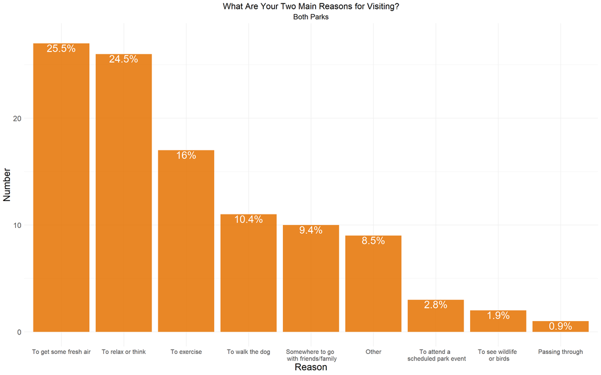

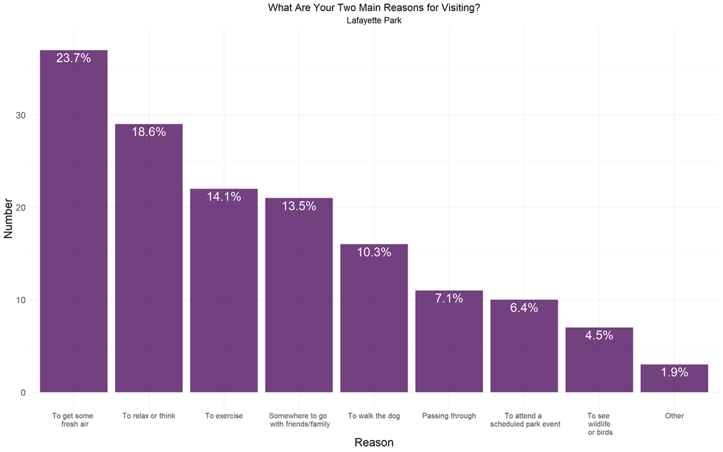

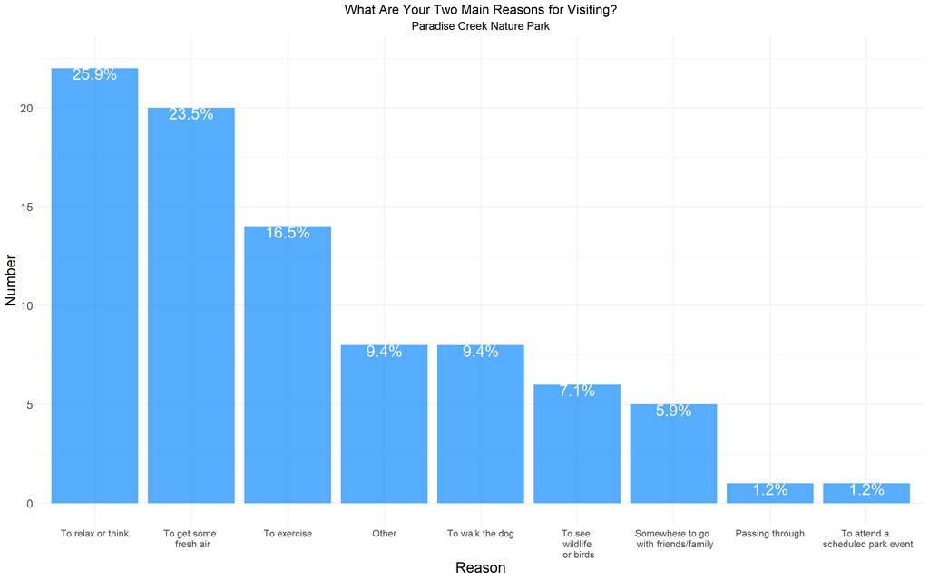

Overall, “To get some fresh air” and “To relax or think” account for 50% of all responses. If we look only at responses related to Lafayette Park, the top three response are the same but we see its use as a gathering place and social importance, while a greater percentage of Paradise Creek Nature Park respondents cite seeing wildlife or birds as a motivation for visiting.

The charts below extend the visualization above and are an attempt to distill the reasons given for visiting the park into one of five broad categories—Exercise, Instrumental (e.g., passing through to a destination, walking the dog), Nature, Restorative, and Social.

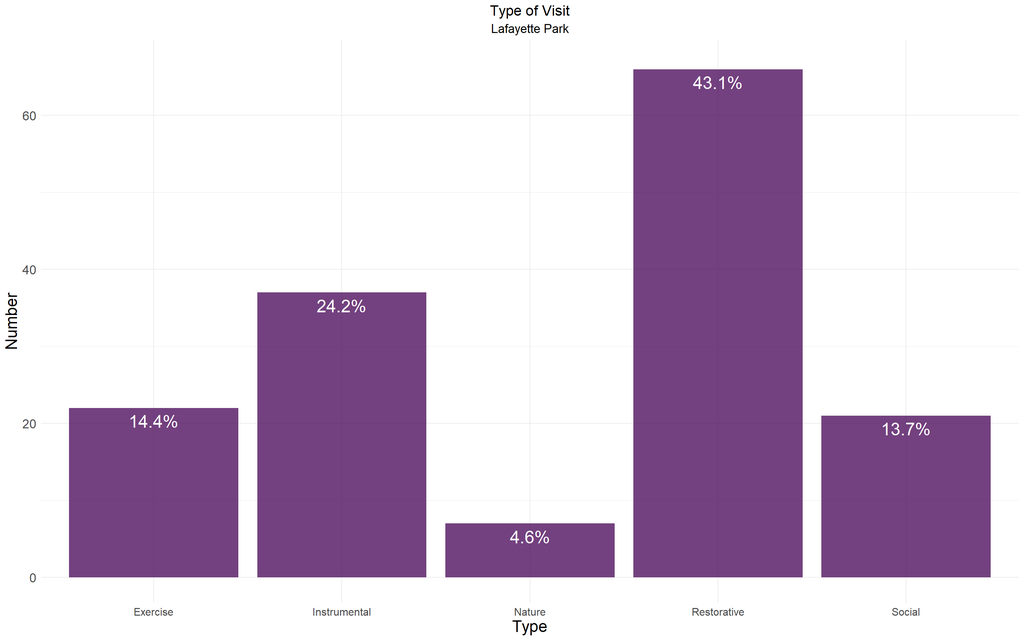

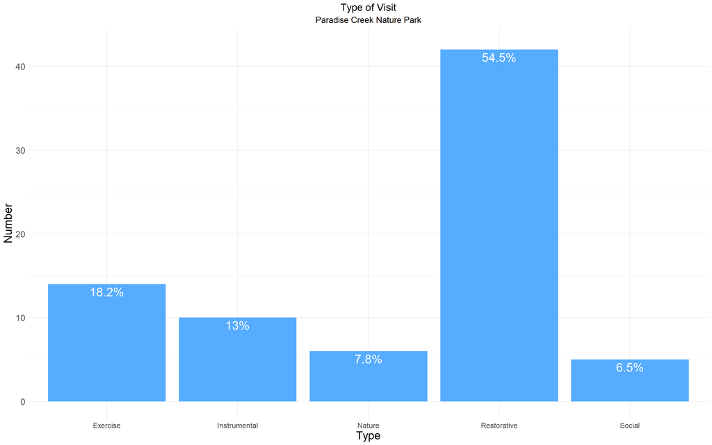

It appears that reported motivations for visiting the two parks are different consistent with our understanding of the functions they best support (e.g., restorative versus social). One does not simply end up in Paradise Creek Nature Park and the lower instrumental visit category suggests that those visits may be more intentional? Restorative visits were more prevalent in Lafayette Park than I had anticipated.

The charts below explore whether respondents typically visit alone or with companions.

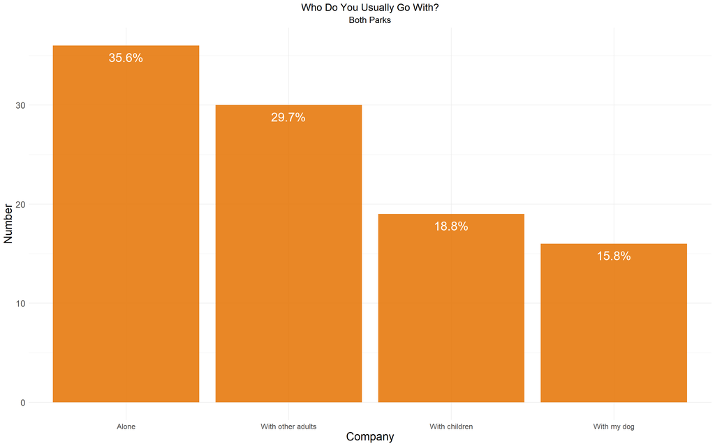

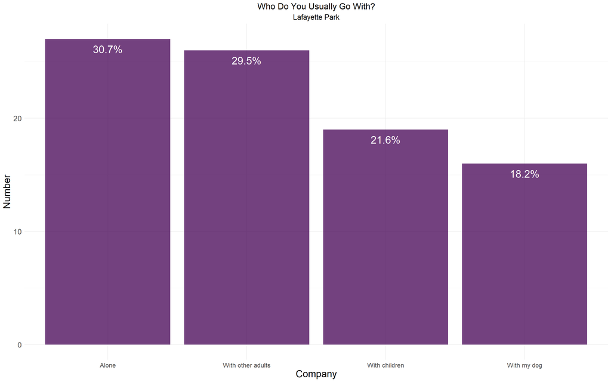

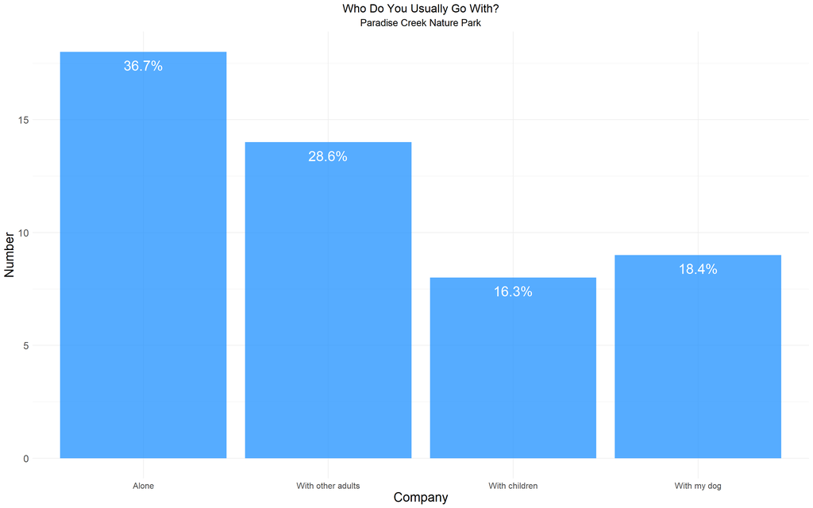

In terms of barriers to visiting the parks, a lack of time to visit, safety concerns, and barriers to pedestrian access (i.e., major roads) were cited by respondents in Norfolk and Portsmouth.

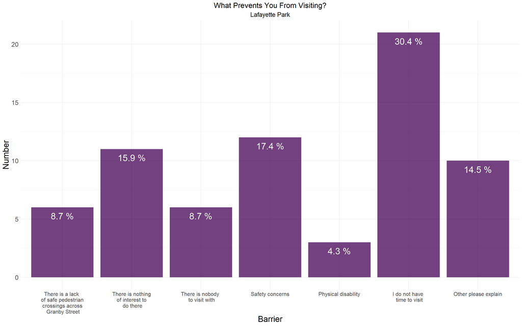

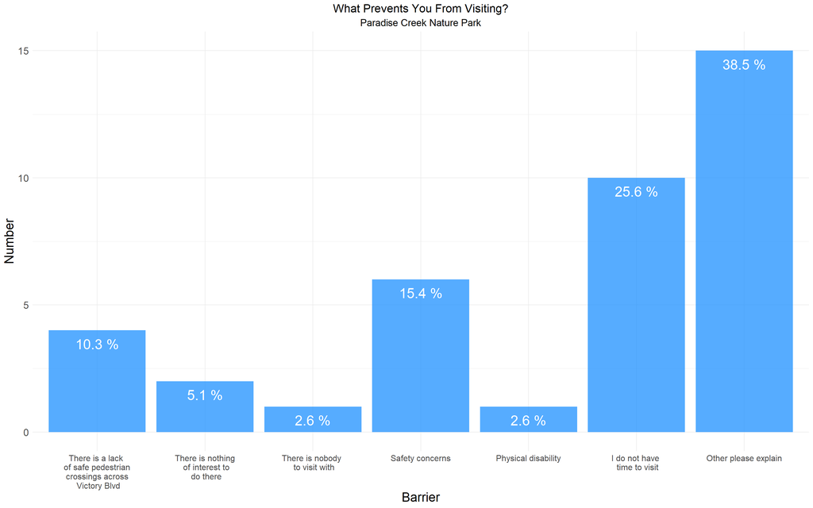

| Lafayette Park | Paradise Creek Nature Park |
| --- | --- |
| nothing preventing me | Nothing |
| Inclimate weather | Weather |
| I visit the park | Do not always feel safe |
| Panhandlers | N/A |
| time | N/A |
| I would like to see a walking trail | Work sometimes |
| Repetitive; enjoy variety & travel. However | Bugs |
| that stability in my home address is desired! Both. | I think that they should have like a panic button or something of that sort throughout the park |
| Nothing particularly I visit like 3 times a week I take my grandkids they love it | none |
| Need of other amenities like splash pad is needed | Sometimes the type of people at the park is suspect |
| nothing prevents | N/A |
| NA | Was not aware of this patk |
| NA | Nothing |
| NA | Snakes |
| NA | Rain |

The table above presents responses provided when “Other” was selected as a barrier to visiting.

#### Correlations with Other Respondent Characteristics

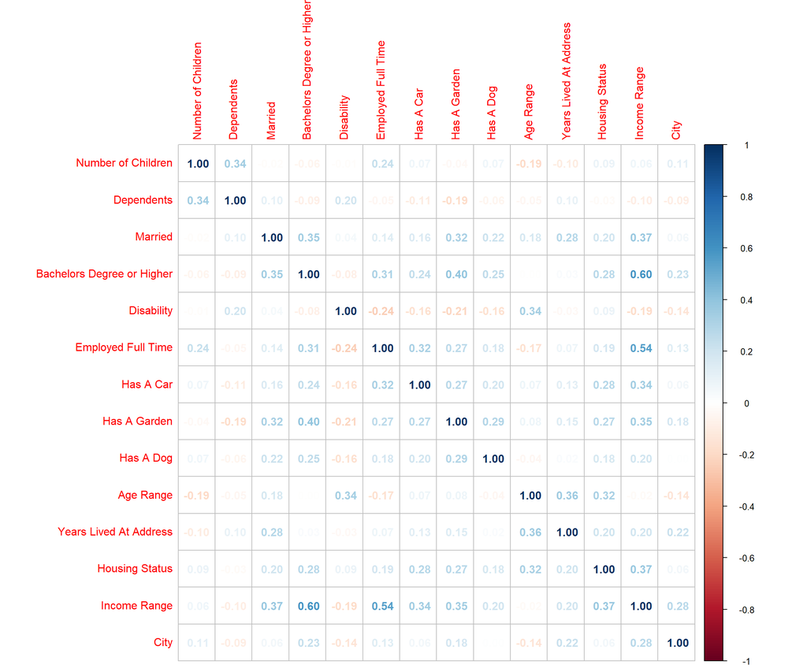

```r
corrplot(cor(correlation_table), method="number")
```

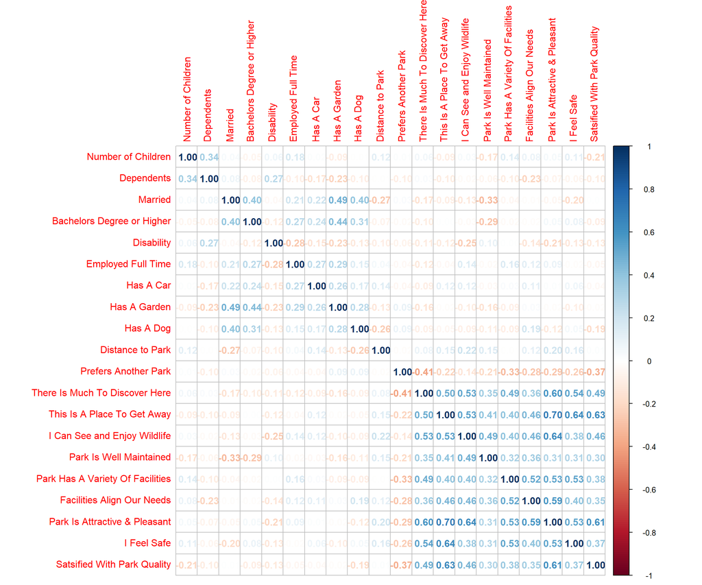

```r
corrplot(cor(correlation_table_with_parks %>% dplyr::select(c(1:20))), method="number")
```

An OLS regression was fit with each of the park perception responses as the dependent variable–this uses the collapsed 3-point scale.

The only significant predictor of responses to the *There is much to explore and discover here* question was whether the respondent indicated that they preferred to visit a different park (R<sup>2</sup> = 0.10).

Preferring another park was the only significant predictor of the response to the *The facilities align with the needs of people who live in my neighborhood* question (R<sup>2</sup> = 0.03).

Linear regression with the collapsed scale variables is not telling us very much.

Logistic regression using the park quality question and the prefer another park question as dependent variables also did not reveal any statistically significant patterns.